# Building intuition into popgen fundamentals and inference

Exercises for the [Workshop on population and speciation genomics](http://evomics.org/workshops/workshop-on-population-and-speciation-genomics/2025-workshop-on-population-and-speciation-genomics-cesky-krumlov/)

Authors

Martin Petr

[CC BY 4.0](https://creativecommons.org/licenses/by/4.0/)

Published

January 2025

# Reference materials

As you will be working on the exercises below (all of which focus on the popgen simulation R package [*slendr*](https://slendr.net)), some reference materials will be useful:

1. First and foremost, you should refer to the **slides with the *slendr* “crash course”** which we started our activity session with, and which cover pretty much every bit of *slendr* functionality you will need. You can find the material rendered as [normal slides](https://bodkan.quarto.pub/cesky-krumlov-2025-slides/) or [one-page handouts](https://bodkan.quarto.pub/cesky-krumlov-2025-handouts/) (the latter will be a bit more practical for reference, as you won’t have to search for information by flipping through individual slides). If these Quarto Pub links are not working, it could be because their servers are overloaded. In this case, you can simply open `slides.html` or `handouts.html` from the [GitHub repository](https://github.com/bodkan/cesky-krumlov-2025/) for this activity (you will have them also in the cloud – instructions below).
2. **[Manual pages](https://www.slendr.net/reference/index.html) of all available *slendr* functions**. Note that you can get the help page of every *slendr* R `function()` by typing `?function` in the R console, and read it directly in the RStudio. For instance, typing `?ts_tajima` gives you the help page of the *tskit*/*slendr* function implementing the tree-based computation of Tajima’s D. Whenever I discuss an optional parameter of some function (or whenever you want to modify a function’s behavior), this is where you can find more information about it.
3. Relevant **tutorials on the [*slendr* website](https://www.slendr.net)** which you can find under the “Articles” link in the header of the webpage. In general, the website contains much more detailed information which is available in the [handouts](https://bodkan.quarto.pub/cesky-krumlov-2025-handouts/) in a much more condensed form. I think this is probably *too much information* for this activity, but don’t hesitate to read a bit more if you’re interested!

# Installation setup

**If you’re using the RStudio browser-based cloud instance provided by the workshop organizes, you don’t actually have to do anything! Just log in to the RStudio session in your browser and navigate to the directory for this activity via `File -> Open Project...` in the RStudio menu (selecting the `cesky-krumlov-2025.Rproj` project file in that directory with open a fresh R session for that project in your RStudio).**

**Setup on your own computer**

**If you want to set up everything on your local machine from scratch (maybe after the workshop is over and you want to return to the material on yor own), just follow the couple of steps right below.**

1. **Clone the repository with the activity materials**. In a shell terminal on Linux or macOS, in your home directory (or anywhere else, really) you can run:

   ```
   $ git clone https://github.com/bodkan/cesky-krumlov-2025 ~/slendr_activity
   ```

(For Windows users: You can download a zip file with the whole course even without git.)

2. **Open RStudio and install all of the following dependencies:**

   ```
   > install.packages(c("slendr", "combinat", "cowplot", "dplyr", "readr",
                        "tidyr", "ggplot2", "rmarkdown", "yaml"))
   ```

3. **Set up the Python environment used by the *slendr* R package** for simulation and tree-sequence analysis (still in the R console!):

   ```
   > slendr::setup_env(agree = TRUE)
   ```

   If everything worked, you should get an optimistic message saying:

   ```
   ======================================================================
   Python environment for slendr has been successfuly created, and the R
   interface to msprime, tskit, and pyslim modules has been activated.

   In future sessions, activate this environment by calling init_env().
   =======================================================================
   ```

4. **Open your RStudio (unless you did the above steps already in RStudio)**, and you’re good to go!

**If the `setup_env()` installation procedure fails, try the following:**

1. Delete the failed installation attempt:

```
slendr::clear_env(force = TRUE, all = TRUE)
```

2. Try installing it again, this time using `pip` as a Python installation method (the default is `conda` which unfortunately fails fairly often):

```
slendr::setup_env(agree = TRUE, pip = TRUE)
```

In every previous installments of this workshop, this is all that was needed to resolve problems.*

**Installing SLiM**

It’s unclear whether we will manage to go through the entirety of the selection-based exercise. However, to be able to do this, having SLiM at least version 4.2 (and it being available in your unix `$PATH!`) is required. If this isn’t possible for your, don’t worry. You’ll be able to do most of that exercise even without SLiM by using cached results of the SLiM simulation that I provided.

# Organization of the exercises

For each exercise, you will get a brief explanation of the problem at hand and some information about functions that could be useful to solve the exercise. **The concrete, specific task will be always written like this in bold. As you work on each part of each exercises, look for these bold lines.**

**Your goal for each exercise is to write a complete R script script (in RStudio `File -> New file -> R script`). I suggest you save the script for each exercise as `exercise1.R`, `exercise2.R`, etc., just to keep things tidy and easy to troubleshoot if needed.**

**Each exercise is composed of individual *parts*, which are designed to build one upon the other in the order they are specified. As you progress through sequential parts of each exercise, you will be adding code to your script for that exercise.**

#### Don’t worry about the number of exercises you’re *“supposed to do”*

How far we manage to crunch through the content of this session will depend on everybody’s level of confidence in programming *and* population genetics. The contents of the activities as a whole are designed so that no matter the moment at which we run out of time, you will take home enough knowledge of *slendr* to be able to immediately apply it to your own projects.

**To avoid anyone getting overwhelmed, I’ll be stopping the activity at some “checkpoints”, to check in with how everything is going and quickly go through the example solutions for the parts until that point, and give a quick explanation.**

If you find yourself way ahead, there are bonus exercises (which I will not be going through with everyone) – those should provide at entertainment and a bit more challenge for you while the rest of us are catching up. If you’re *really* far ahead, just continue to the next exercise without waiting for the rest of us.

#### Note on the programming aspect of the exercises

All the exercises will involve “real coding”! If you’ve never really programmed entire scripts before, this could feel a little intimidating. Don’t worry. If you’re ever lost, just take a peek at the solutions which are (by default hidden) under each exercise part. Always try to work on a solution on your own, but never let this be a barrier to your progress. Feel free to copy-paste bits of my solutions into your own scripts.

If you find yourself [*totally lost*](https://scryfall.com/card/gtc/54/totally-lost), don’t hesitate to read my solutions from the get go, copy-pasting them into your own script in the RStudio, executing them line by line, and trying to understand what’s going on. **It’s the understanding that we’re after here. Whether or not you can implement everything yourself from scratch does not actually matter at all.** (Nobody in history has learned to program from scratch. Everyone started by copy-pasting code examples written by someone else.)

# Exercise 1: Programming demographic models with *slendr*

### Part 1: Building a demographic model in *slendr*

**Use functions such as `population()`, `gene_flow()`, and `compile_model()`, which we discussed in the [“crash course”](https://bodkan.quarto.pub/cesky-krumlov-2025-handouts/) at the start of this session, to program the following toy model of human demographic history in *slendr*.** (Apologies for my bad handwriting and poor artistic ability.)

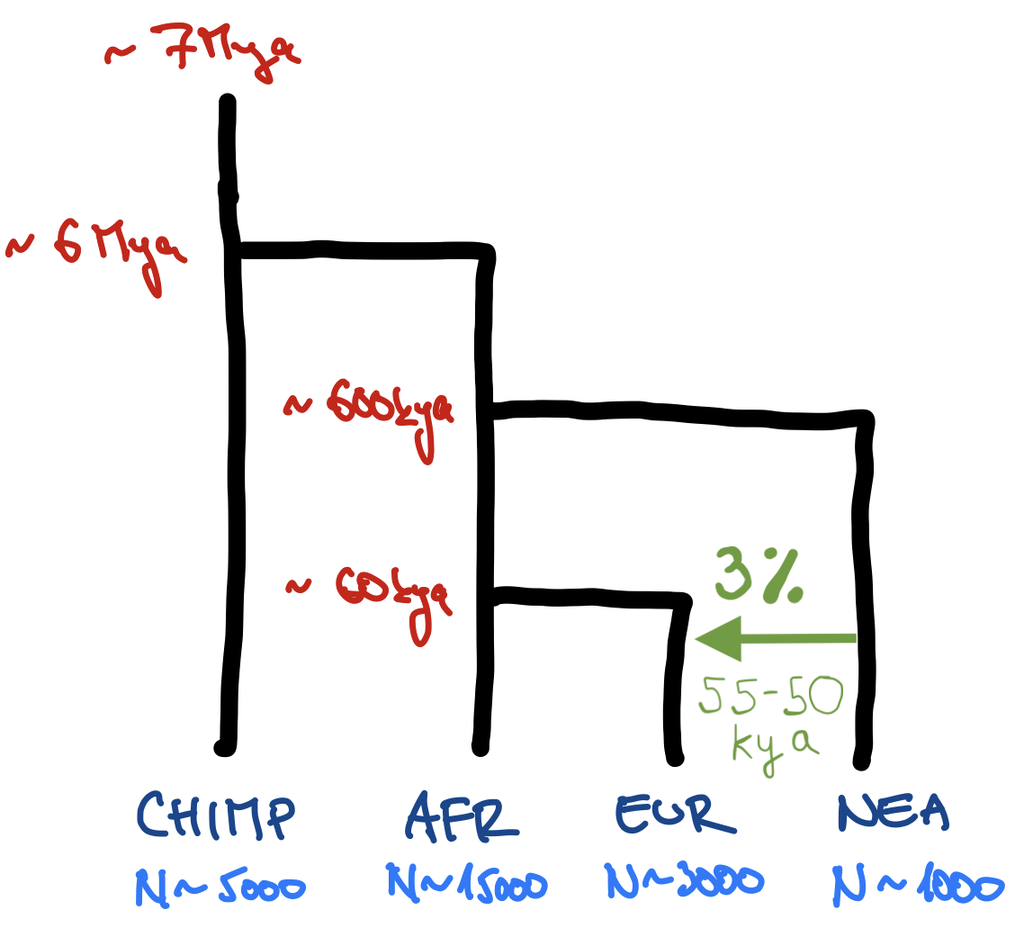

**Note:** You could easily program the model so that different ancestral populations are represented by separate `population()` commands (i.e., your model would start with a population called “human_chimp_ancestor” from which a “CHIMP” and “hominin_ancestor” populations would split at 6 Mya, etc.) but generally this is too annoying to do and requires too much code.

Feel free to write the model so that “CHIMP” is the first population, then “AFR” population splits from it at 6 Mya, etc… Although it probably isn’t the most accurate way to describe the real evolutionary history, it simplifies the coding significantly.

[Mya = million years ago; kya = thousand years ago]

**Hint:** Start script `exercise1.R` script in your RStudio session using the following “template”. Then add a sequence of appropriate `population()` calls using the syntax from the introductory slides (using the `parent = <pop>` argument for programming splits of daughter populations – which will be all except the CHIMP lineage in our example), etc.

```r
library(slendr)
init_env()

<... population definitions ...>
<... gene-flow definition ...>

model <- compile_model(
  populations = list(...),
  gene_flow = <...>,
  generation_time = 30
)
```

**Note:** With *slendr* you can specify time in whatever format is more convenient or readable for your model. For instance here, because we’re dealing with historical events which are commonly expressed in times given as”years ago”, we can write them in a decreasing order – i.e. 7Mya → 6Mya → …, as shown above – or, in terms of R code, 7e6 (or 7000000), 6e6 (6000000), etc.

In a later example, you will see that you can also encode the events in the time direction going “forward” (i.e., the first event starting in generation 1, a following event in generation 42, and so on).

**Hint:** Remember that *slendr* is designed with interactivity in mind! When you write a chunk of code (such as a command to create a population through a population split, or model compilation to create a `model` object), execute that bit of code in the R console and inspect the summary information printed by evaluating the respective R object you just created. You can either copy-pasted stuff from your script to the R console, or used a convenient RStudio shortcut like Ctrl+Enter (Linux and Windows), or Cmd+Enter (Mac).

**Click to see the solution**

```r
library(slendr)
init_env()
## The interface to all required Python modules has been activated.

# Chimpanzee outgroup
chimp <- population("CHIMP", time = 7e6, N = 5000)

# Two populations of anatomically modern humans: Africans and Europeans
afr <- population("AFR", parent = chimp, time = 6e6, N = 15000)
eur <- population("EUR", parent = afr, time = 70e3, N = 3000)

# Neanderthal population splitting at 600 ky ago from modern humans
# (becomes extinct by 40 ky ago)
nea <- population("NEA", parent = afr, time = 600e3, N = 1000, remove = 40e3)

# Neanderthal introgression event (3% admixture between 55-50 kya)
gf <- gene_flow(from = nea, to = eur, rate = 0.03, start = 55000, end = 50000)

# Compile the entire model into a single slendr R object
model <- compile_model(
  populations = list(chimp, nea, afr, eur),
  gene_flow = gf,
  generation_time = 30,
  path = here::here("data/introgression"),  # <--- don't worry about these two
  overwrite = TRUE, force = TRUE            # <--- lines of code (ask me if interested)
)
```

### Part 2: Inspecting the model visually

To visualize a *slendr* model, you use the function `plot_model()`. **Plot your compiled `model` to make sure you programmed it correctly!** Your figure should roughly correspond to my doodle above.

**Note:** Plotting of models in *slendr* can be sometimes a little wonky, especially if many things are happening at once. When plotting your model, experiment with arguments `log = TRUE`, `proportions = TRUE`, `gene_flow = TRUE`. Check `?plot_model` for more information on these.

**Click to see the solution**

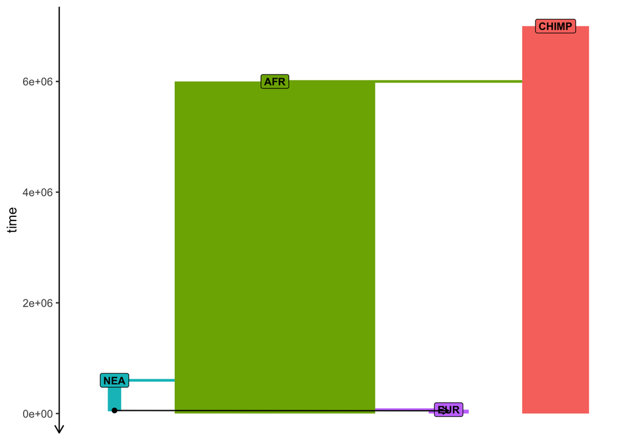

```r
plot_model(model)
```

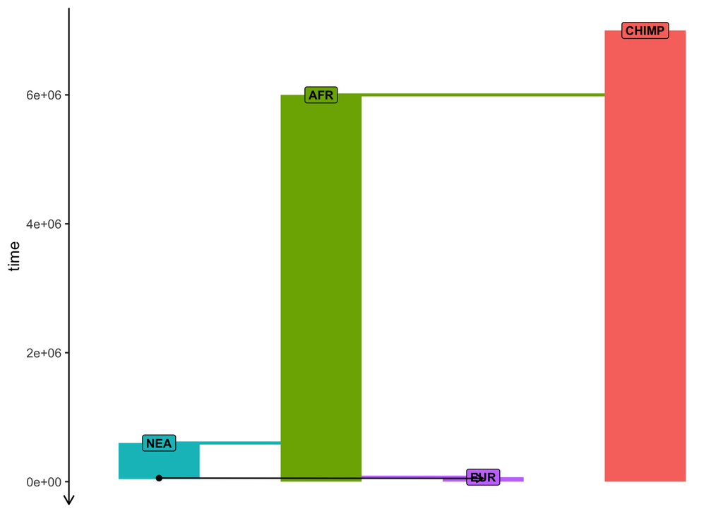

```r
plot_model(model, sizes = FALSE)
```

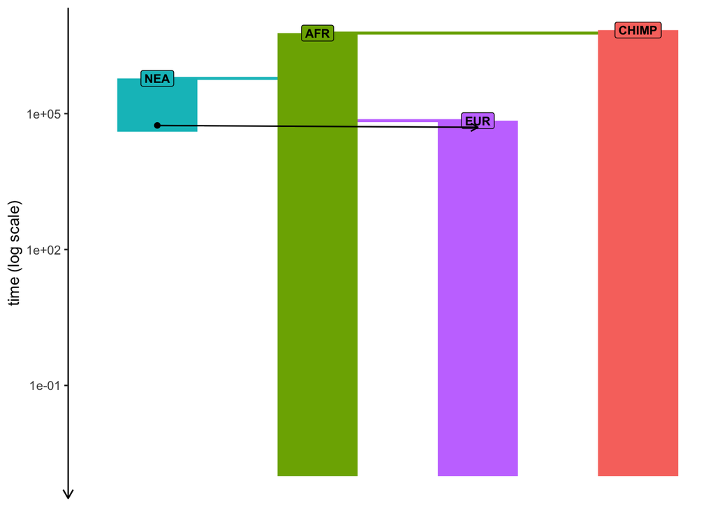

```r
plot_model(model, sizes = FALSE, log = TRUE)
```

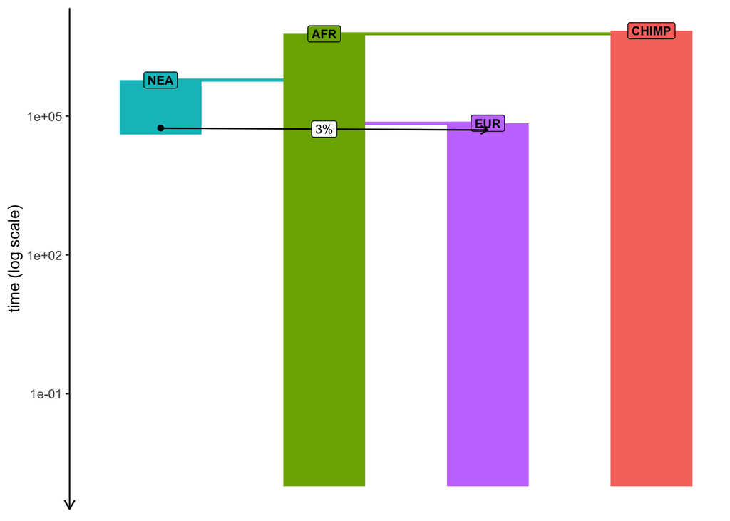

```r
plot_model(model, sizes = FALSE, log = TRUE, proportions = TRUE)
```

### Part 3: Simulating genomic data

Once you have a compiled *slendr* model stored in an R variable (from now on, `model` will always mean a variable containing a compiled *slendr* model object relevant for the given exercise, for simplicity), we can simulate data from it. By default, *slendr* models always produce a [tree sequence](https://tskit.dev/tutorials/what_is.html).

**Note:** Tree sequence provides an extremely efficient means to store and work with genomic data at a massive scale. However, you can always get simulated data even in [traditional file formats](https://www.slendr.net/reference/index.html#tree-sequence-format-conversion), such as VCF, EIGENSTRAT, or a plain old table of ancestral/derived genotypes.

In this activity we will be only working with tree sequences, because it’s much easier and faster to get interesting statistics from it directly in R.

There are two simulation engines built into *slendr* implemented by functions `msprime()` and `slim()`. For traditional, non-spatial, neutral demographic models, the engine provided by the `msprime()` function is much more efficient, so we’ll be using that for the time being. However, from a popgen theoretical perspective, both simulation functions will give you the same results for any given compiled *slendr* model (up to some level of stochastic noise, of course).

**Note:** Yes, this means you don’t have to write any *msprime* (or SLiM) code to simulate data from a *slendr* model!

Here’s how you can use the function to simulate a tree sequence from the model you’ve just created using `compile_model()` in your script:

```r
ts <- msprime(
  model,
  sequence_length = <length of sequence to simulate [as bp]>,
  recombination_rate = <uniform recombination rate [per bp per generation]>
)
```

You will be seeing this kind of pattern over and over again in this exercise, so it’s a good idea to keep it in mind.

**Hint:** The `msprime()` function has also arguments `debug` and `run` which can be extremely useful for debugging.

**Simulate a tree sequence from your compiled `model` using the `msprime()` engine, storing it to a variable `ts` as shown right above. Use `sequence_length = 1e6` (so 1 Mb of sequence) and `recombination_rate = 1e-8` (crossover events per base pair per generation). Then experiment with setting `debug = TRUE` (this prints out *msprime*’s own debugging summary which you might already be familiar with from your previous activity?) and then `run = FALSE` (this prints out a raw command-line which can run a *slendr* simulation in the shell).**

**Click to see the solution**

```r
# This simulates a tskit tree sequence from a slendr model. Note that you didn't have
# to write any msprime or tskit Python code!
ts <- msprime(model, sequence_length = 1e6, recombination_rate = 1e-8)

# Setting `debug = TRUE` instructs slendr's built-in msprime script to print
# out msprime's own debugger information. This can be very useful for debugging,
# in addition to the visualization of the model as shown above.
ts <- msprime(model, sequence_length = 1e6, recombination_rate = 1e-8, debug = TRUE)
## DemographyDebugger
## ╠═════════════════════════════════════╗
## ║ Epoch[0]: [0, 1.67e+03) generations ║
## ╠═════════════════════════════════════╝
## ╟    Populations (total=4 active=4)
## ║    ┌─────────────────────────────────────────────────────────────────────┐
## ║    │       │     start│       end│growth_rate  │ CHIMP │ AFR │ NEA │ EUR │
## ║    ├─────────────────────────────────────────────────────────────────────┤
## ║    │  CHIMP│    5000.0│    5000.0│ 0           │   0   │  0  │  0  │  0  │
## ║    │    AFR│   15000.0│   15000.0│ 0           │   0   │  0  │  0  │  0  │
## ║    │    NEA│    1000.0│    1000.0│ 0           │   0   │  0  │  0  │  0  │
## ║    │    EUR│    3000.0│    3000.0│ 0           │   0   │  0  │  0  │  0  │
## ║    └─────────────────────────────────────────────────────────────────────┘
## ╟    Events @ generation 1.67e+03
## ║    ┌─────────────────────────────────────────────────────────────────────────────────────────┐
## ║    │  time│type            │parameters              │effect                                  │
## ║    ├─────────────────────────────────────────────────────────────────────────────────────────┤
## ║    │  1666│Migration rate  │source=EUR, dest=NEA,   │Backwards-time migration rate from EUR  │
## ║    │      │change          │rate=0.000179640718562  │to NEA → 0.00017964071856287425         │
## ║    │      │                │87425                   │                                        │
## ║    └─────────────────────────────────────────────────────────────────────────────────────────┘
## ╠════════════════════════════════════════════╗
## ║ Epoch[1]: [1.67e+03, 1.83e+03) generations ║
## ╠════════════════════════════════════════════╝
## ╟    Populations (total=4 active=4)
## ║    ┌───────────────────────────────────────────────────────────────────────────┐
## ║    │       │     start│       end│growth_rate  │ CHIMP │ AFR │    NEA    │ EUR │
## ║    ├───────────────────────────────────────────────────────────────────────────┤
## ║    │  CHIMP│    5000.0│    5000.0│ 0           │   0   │  0  │     0     │  0  │
## ║    │    AFR│   15000.0│   15000.0│ 0           │   0   │  0  │     0     │  0  │
## ║    │    NEA│    1000.0│    1000.0│ 0           │   0   │  0  │     0     │  0  │
## ║    │    EUR│    3000.0│    3000.0│ 0           │   0   │  0  │ 0.0001796 │  0  │
## ║    └───────────────────────────────────────────────────────────────────────────┘
## ╟    Events @ generation 1.83e+03
## ║    ┌────────────────────────────────────────────────────────────────────────────────────────┐
## ║    │  time│type            │parameters             │effect                                  │
## ║    ├────────────────────────────────────────────────────────────────────────────────────────┤
## ║    │  1833│Migration rate  │source=EUR, dest=NEA,  │Backwards-time migration rate from EUR  │
## ║    │      │change          │rate=0                 │to NEA → 0                              │
## ║    │┈┈┈┈┈┈┈┈┈┈┈┈┈┈┈┈┈┈┈┈┈┈┈┈┈┈┈┈┈┈┈┈┈┈┈┈┈┈┈┈┈┈┈┈┈┈┈┈┈┈┈┈┈┈┈┈┈┈┈┈┈┈┈┈┈┈┈┈┈┈┈┈┈┈┈┈┈┈┈┈┈┈┈┈┈┈┈┈│
## ║    │  1833│Census          │                       │Insert census nodes to record the       │
## ║    │      │                │                       │location of all lineages                │
## ║    └────────────────────────────────────────────────────────────────────────────────────────┘
## ╠════════════════════════════════════════════╗
## ║ Epoch[2]: [1.83e+03, 2.33e+03) generations ║
## ╠════════════════════════════════════════════╝
## ╟    Populations (total=4 active=4)
## ║    ┌─────────────────────────────────────────────────────────────────────┐
## ║    │       │     start│       end│growth_rate  │ CHIMP │ AFR │ NEA │ EUR │
## ║    ├─────────────────────────────────────────────────────────────────────┤
## ║    │  CHIMP│    5000.0│    5000.0│ 0           │   0   │  0  │  0  │  0  │
## ║    │    AFR│   15000.0│   15000.0│ 0           │   0   │  0  │  0  │  0  │
## ║    │    NEA│    1000.0│    1000.0│ 0           │   0   │  0  │  0  │  0  │
## ║    │    EUR│    3000.0│    3000.0│ 0           │   0   │  0  │  0  │  0  │
## ║    └─────────────────────────────────────────────────────────────────────┘
## ╟    Events @ generation 2.33e+03
## ║    ┌───────────────────────────────────────────────────────────────────────────┐
## ║    │  time│type        │parameters      │effect                                │
## ║    ├───────────────────────────────────────────────────────────────────────────┤
## ║    │  2333│Population  │derived=[EUR],  │Moves all lineages from the 'EUR'     │
## ║    │      │Split       │ancestral=AFR   │derived population to the ancestral   │
## ║    │      │            │                │'AFR' population. Also set 'EUR' to   │
## ║    │      │            │                │inactive, and all migration rates to  │
## ║    │      │            │                │and from the derived population to    │
## ║    │      │            │                │zero.                                 │
## ║    └───────────────────────────────────────────────────────────────────────────┘
## ╠═════════════════════════════════════════╗
## ║ Epoch[3]: [2.33e+03, 2e+04) generations ║
## ╠═════════════════════════════════════════╝
## ╟    Populations (total=4 active=3)
## ║    ┌───────────────────────────────────────────────────────────────┐
## ║    │       │     start│       end│growth_rate  │ CHIMP │ AFR │ NEA │
## ║    ├───────────────────────────────────────────────────────────────┤
## ║    │  CHIMP│    5000.0│    5000.0│ 0           │   0   │  0  │  0  │
## ║    │    AFR│   15000.0│   15000.0│ 0           │   0   │  0  │  0  │
## ║    │    NEA│    1000.0│    1000.0│ 0           │   0   │  0  │  0  │
## ║    └───────────────────────────────────────────────────────────────┘
## ╟    Events @ generation 2e+04
## ║    ┌────────────────────────────────────────────────────────────────────────────┐
## ║    │   time│type        │parameters      │effect                                │
## ║    ├────────────────────────────────────────────────────────────────────────────┤
## ║    │  2e+04│Population  │derived=[NEA],  │Moves all lineages from the 'NEA'     │
## ║    │       │Split       │ancestral=AFR   │derived population to the ancestral   │
## ║    │       │            │                │'AFR' population. Also set 'NEA' to   │
## ║    │       │            │                │inactive, and all migration rates to  │
## ║    │       │            │                │and from the derived population to    │
## ║    │       │            │                │zero.                                 │
## ║    └────────────────────────────────────────────────────────────────────────────┘
## ╠══════════════════════════════════════╗
## ║ Epoch[4]: [2e+04, 2e+05) generations ║
## ╠══════════════════════════════════════╝
## ╟    Populations (total=4 active=2)
## ║    ┌─────────────────────────────────────────────────────────┐
## ║    │       │     start│       end│growth_rate  │ CHIMP │ AFR │
## ║    ├─────────────────────────────────────────────────────────┤
## ║    │  CHIMP│    5000.0│    5000.0│ 0           │   0   │  0  │
## ║    │    AFR│   15000.0│   15000.0│ 0           │   0   │  0  │
## ║    └─────────────────────────────────────────────────────────┘
## ╟    Events @ generation 2e+05
## ║    ┌──────────────────────────────────────────────────────────────────────────────┐
## ║    │   time│type        │parameters       │effect                                 │
## ║    ├──────────────────────────────────────────────────────────────────────────────┤
## ║    │  2e+05│Population  │derived=[AFR],   │Moves all lineages from the 'AFR'      │
## ║    │       │Split       │ancestral=CHIMP  │derived population to the ancestral    │
## ║    │       │            │                 │'CHIMP' population. Also set 'AFR' to  │
## ║    │       │            │                 │inactive, and all migration rates to   │
## ║    │       │            │                 │and from the derived population to     │
## ║    │       │            │                 │zero.                                  │
## ║    └──────────────────────────────────────────────────────────────────────────────┘
## ╠════════════════════════════════════╗
## ║ Epoch[5]: [2e+05, inf) generations ║
## ╠════════════════════════════════════╝
## ╟    Populations (total=4 active=1)
## ║    ┌─────────────────────────────────────────┐
## ║    │       │    start│      end│growth_rate  │
## ║    ├─────────────────────────────────────────┤
## ║    │  CHIMP│   5000.0│   5000.0│ 0           │
## ║    └─────────────────────────────────────────┘

# For debugging of technical issues (with msprime, with slendr, or both), it is
# very useful to have the `msprime` function dump the "raw" command-line to
# run the simulation on the terminal using plain Python interpreter
msprime(model, sequence_length = 1e6, recombination_rate = 1e-8, run = FALSE)
## /Users/mp/Library/r-miniconda-arm64/envs/Python-3.12_msprime-1.3.3_tskit-0.5.8_pyslim-1.0.4_tspop-0.0.2/bin/python /Users/mp/Projects/cesky-krumlov-2025/data/introgression/script.py --seed 49514722 --model /Users/mp/Projects/cesky-krumlov-2025/data/introgression --sequence-length 1000000 --recombination-rate 1e-08    --path <path to a .trees file>
```

### Part 4: Inspecting the tree-sequence object

As we will see later, *slendr* provides an R-friendly interface to accessing a [subset of *tskit*’s functionality](https://tskit.dev/tskit/docs/stable/python-api.html) for working with tree sequence and for computing various popgen statistics.

For now, **type out the `ts` object in the terminal – what do you see?** You should get a summary of a tree-sequence object that you’re familiar with from your *msprime* and *tskit* activity earlier in the day.

This is a very important feature of *slendr* – when a simulation is concluded (doesn’t matter if it was a `slim()` or `msprime()` simulation), you will get a normal *tskit* object. In fact, the fact that *slendr* supports (so far, and likely always) only a “subset” of all of *tskit*’s functionality isn’t stopping you to write custom Python/*tskit* processing code of a tree sequence generated from a *slendr* model. Under the hood, a *slendr* simulation *really is* just an *msprime* (or SLiM) simulation! It’s just executed through a simplified interface (and dare I say a bit more convenient, for some purposes).

**Click to see the solution**

```r
# Typing out the object with the result shows that it's a good old tskit
# tree-sequence object
ts
```

```
╔═══════════════════════════╗
║TreeSequence               ║
╠═══════════════╤═══════════╣
║Trees          │       9705║
╟───────────────┼───────────╢
║Sequence Length│    1000000║
╟───────────────┼───────────╢
║Time Units     │generations║
╟───────────────┼───────────╢
║Sample Nodes   │      48000║
╟───────────────┼───────────╢
║Total Size     │    8.9 MiB║
╚═══════════════╧═══════════╝
╔═══════════╤══════╤═════════╤════════════╗
║Table      │Rows  │Size     │Has Metadata║
╠═══════════╪══════╪═════════╪════════════╣
║Edges      │134933│  4.1 MiB│          No║
╟───────────┼──────┼─────────┼────────────╢
║Individuals│ 24000│656.3 KiB│          No║
╟───────────┼──────┼─────────┼────────────╢
║Migrations │     0│  8 Bytes│          No║
╟───────────┼──────┼─────────┼────────────╢
║Mutations  │     0│ 16 Bytes│          No║
╟───────────┼──────┼─────────┼────────────╢
║Nodes      │105165│  2.8 MiB│          No║
╟───────────┼──────┼─────────┼────────────╢
║Populations│     4│341 Bytes│         Yes║
╟───────────┼──────┼─────────┼────────────╢
║Provenances│     1│  2.7 KiB│          No║
╟───────────┼──────┼─────────┼────────────╢
║Sites      │     0│ 16 Bytes│          No║
╚═══════════╧══════╧═════════╧════════════╝
```

The brilliance of the tree-sequence data structure rests on its elegant table-based implementation (much more information on that is [here](https://tskit.dev/tskit/docs/stable/data-model.html)). *slendr* isn’t really designed to run very complex low-level manipulations of tree-sequence data (it’s strength lies in the convenient interface to popgen statistical functions implemented by *tskit*), but it does contain a couple of functions which can be useful for inspecting the lower-level nature of a tree sequence. Let’s look at a couple of them now.

**Click to see the solution**

```r
# slendr provides a helper function which allows access to all the low-level
# components of every tree-sequence object
ts_table(ts, "nodes")
```

```
# A tibble: 105,165 × 5
   node_id    ind_id pop_id  time time_tskit
     <int> <int[1d]>  <int> <dbl>      <dbl>
 1       0         0      0     0          0
 2       1         0      0     0          0
 3       2         1      0     0          0
 4       3         1      0     0          0
 5       4         2      0     0          0
 6       5         2      0     0          0
 7       6         3      0     0          0
 8       7         3      0     0          0
 9       8         4      0     0          0
10       9         4      0     0          0
# ℹ 105,155 more rows
```

```r
ts_table(ts, "edges")
```

```
# A tibble: 134,933 × 5
      id child parent  left   right
   <dbl> <int>  <int> <dbl>   <dbl>
 1     0 15325  48000     0 1000000
 2     1 19919  48000     0 1000000
 3     2  1218  48001     0 1000000
 4     3  7250  48001     0 1000000
 5     4 46468  48002     0 1000000
 6     5 47285  48002     0 1000000
 7     6 12524  48003     0 1000000
 8     7 29081  48003     0 1000000
 9     8  4788  48004     0 1000000
10     9  6808  48004     0 1000000
# ℹ 134,923 more rows
```

```r
ts_table(ts, "individuals")
```

```
# A tibble: 24,000 × 5
   ind_id  time    pop_id time_tskit sampled
    <dbl> <dbl> <int[1d]>  <dbl[1d]> <lgl>
 1      0     0         0          0 TRUE
 2      1     0         0          0 TRUE
 3      2     0         0          0 TRUE
 4      3     0         0          0 TRUE
 5      4     0         0          0 TRUE
 6      5     0         0          0 TRUE
 7      6     0         0          0 TRUE
 8      7     0         0          0 TRUE
 9      8     0         0          0 TRUE
10      9     0         0          0 TRUE
# ℹ 23,990 more rows
```

```r
# We didn't simulate any mutations, so we only have genealogies for now.
ts_table(ts, "mutations")
```

```
# A tibble: 0 × 5
# ℹ 5 variables: id <dbl>, site <int>, node <int>, time <dbl>, time_tskit <dbl>
```

```r
ts_table(ts, "sites")
```

```
# A tibble: 0 × 2
# ℹ 2 variables: id <dbl>, position <dbl>
```

There are also two *slendr*-specific functions called `ts_samples()` (which retrieves the “symbolic names” and dates of all recorded individuals at the end of a simulation) and `ts_nodes()`. **You can run them simply as `ts_samples(ts)` and `ts_nodes(ts)`. How many individuals (samples) are in your tree sequence as you simulated it? How is the result of `ts_nodes()` different from `ts_samples()`?**

**Click to see the solution**

```r
# slendr provides a convenient function `ts_samples()` which allows us to
# inspect the contents of a simulated tree sequence in a more human-readable,
# simplified way. We can see that our tree sequence contains a massive number
# of individuals. Too many, in fact -- we recorded every single individual alive
# at the end of our simulation, which is something we're unlikely to be ever lucky
# enough to have, regardless of which species we study.
ts_samples(ts)
```

```
# A tibble: 24,000 × 3
   name    time pop
   <chr>  <dbl> <chr>
 1 AFR_1      0 AFR
 2 AFR_2      0 AFR
 3 AFR_3      0 AFR
 4 AFR_4      0 AFR
 5 AFR_5      0 AFR
 6 AFR_6      0 AFR
 7 AFR_7      0 AFR
 8 AFR_8      0 AFR
 9 AFR_9      0 AFR
10 AFR_10     0 AFR
# ℹ 23,990 more rows
```

```r
ts_samples(ts) %>% nrow()
```

```
[1] 24000
```

```r
library(dplyr)
ts_samples(ts) %>% group_by(pop) %>% tally
```

```
# A tibble: 4 × 2
  pop       n
  <chr> <int>
1 AFR   15000
2 CHIMP  5000
3 EUR    3000
4 NEA    1000
```

```r
# This function returns a table similar to the one produced by `ts_table(ts, "nodes")`
# above, except that it contains additional slendr metadata (names of individuals
# belonging to each node, spatial coordinates of nodes for spatial models, etc.).
# It's a bit more useful for analyzing tree-sequence data than the "low-level" functions.
ts_nodes(ts)
```

```
# A tibble: 105,165 × 8
   name  pop   ind_id node_id  time time_tskit sampled pop_id
   <chr> <fct>  <dbl>   <int> <dbl>      <dbl> <lgl>    <int>
 1 AFR_1 AFR     5000   10000     0          0 TRUE         1
 2 AFR_1 AFR     5000   10001     0          0 TRUE         1
 3 AFR_2 AFR     5001   10002     0          0 TRUE         1
 4 AFR_2 AFR     5001   10003     0          0 TRUE         1
 5 AFR_3 AFR     5002   10004     0          0 TRUE         1
 6 AFR_3 AFR     5002   10005     0          0 TRUE         1
 7 AFR_4 AFR     5003   10006     0          0 TRUE         1
 8 AFR_4 AFR     5003   10007     0          0 TRUE         1
 9 AFR_5 AFR     5004   10008     0          0 TRUE         1
10 AFR_5 AFR     5004   10009     0          0 TRUE         1
# ℹ 105,155 more rows
```